# Single-Cell Metadata QC Comparison

- Show All Code
- Hide All Code
- View Source

metadata.v2024.2.4.0.parquet (HCA CellxGene 2024) vs metadata.v2025.0.2.0.parquet (HCA CellxGene 2025)

Author

Mengyuan Shen shen.m@wehi.edu.au

Published

September 11, 2026

```r
library(duckdb)
library(dplyr)
library(dbplyr)
library(ggplot2)
library(patchwork)
library(scales)
library(tidyr)
library(stringr)
library(knitr)
library(kableExtra)
library(cellNexus)

# ── colour palette (keys must match atlas_id values in parquet) ─────────────
cell_quality_cols <- c(
  "Empty Droplet" = "#bdbdbd",
  "Alive Cells"   = "#8dd3c7",
  "Dead"          = "#fb8072",
  "Doublet"       = "#bebada"
)

# ── helper: pretty percent ───────────────────────────────────────────────────
pct <- function(x, digits = 2) paste0(round(x * 100, digits), "%")
```

## Overview

This report compares two releases of the **CellNexus** single-cell metadata corpus: corpus scale (cells, datasets, samples, donors, tissues, cell types), new tissues in 2025, and quality-control (QC) metrics:

[output not shown]

Three QC flags are examined:

- **Empty droplet** — cell is flagged as an empty droplet (`empty_droplet == TRUE`)
- **Dead** — cell is non-empty **and** `alive == FALSE`
- **Doublet** — cell is non-empty **and** `scDblFinder.class == "doublet"`

## 1 Data Loading

```r
cells <- get_metadata(cloud_metadata = get_metadata_url(databases = c(
  "metadata.v2024.2.4.0.parquet",
  "metadata.v2025.0.2.0.parquet"
)))

atlas_ids <- cells |>
  distinct(atlas_id) |>
  arrange(atlas_id) |>
  collect() |>
  pull(atlas_id)

pal <- setNames(c("#F28E2B", "#4E79A7"), atlas_ids)
atlas_labels <- setNames(
  c("HCA 2024 (v2.4.0)", "HCA 2025 (v1.0.1)"),
  atlas_ids
)

id_2024 <- atlas_ids[str_detect(atlas_ids, "2024")][1]
id_2025 <- atlas_ids[str_detect(atlas_ids, "2025")][1]

stack_cols <- c(
  "2024" = "#F28E2B",
  "2025_extra" = "#4E79A7"
)
stack_labels <- c(
  "2024" = "2024",
  "2025_extra" = "2025 (additional)"
)

plot_2024_2025_stack <- function(data, y_var, xlab, title, subtitle) {
  y <- rlang::sym(y_var)
  data |>
    pivot_longer(
      cols = c(n_2024, n_2025_extra),
      names_to = "segment",
      values_to = "count"
    ) |>
    mutate(
      segment = recode(segment, n_2024 = "2024", n_2025_extra = "2025_extra"),
      segment = factor(segment, levels = c("2024", "2025_extra"))
    ) |>
    ggplot(aes(x = count, y = reorder(!!y, total), fill = segment)) +
    geom_col(position = position_stack(reverse = TRUE), width = 0.8) +
    scale_fill_manual(values = stack_cols, labels = stack_labels, name = NULL) +
    scale_x_continuous(labels = comma, expand = expansion(mult = c(0, 0.05))) +
    labs(title = title, subtitle = subtitle, x = xlab, y = NULL) +
    theme_minimal(base_size = 11) +
    theme(legend.position = "bottom")
}
```

## 2 Corpus summary

```r
corpus_summary <- cells |>
  group_by(atlas_id) |>
  summarise(
    cell_count                  = n(),
    dataset_count               = n_distinct(dataset_id),
    sample_count                = n_distinct(sample_id),
    donor_count                 = n_distinct(donor_id),
    tissue_count                = n_distinct(tissue),
    cell_type_unified_ensemble_count = n_distinct(cell_type_unified_ensemble),
    .groups = "drop"
  ) |>
  collect()
```

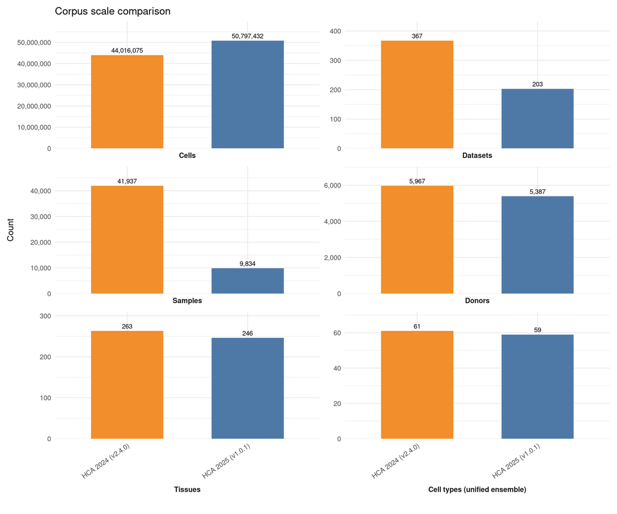

```r
corpus_summary_long <- corpus_summary |>
  pivot_longer(-atlas_id, names_to = "metric", values_to = "count") |>
  mutate(
    atlas_label = atlas_labels[atlas_id],
    metric = recode(
      metric,
      cell_count = "Cells",
      dataset_count = "Datasets",
      sample_count = "Samples",
      donor_count = "Donors",
      tissue_count = "Tissues",
      cell_type_unified_ensemble_count = "Cell types (unified ensemble)"
    ),
    metric = factor(metric, levels = c(
      "Cells", "Datasets", "Samples", "Donors",
      "Tissues", "Cell types (unified ensemble)"
    ))
  )

ggplot(corpus_summary_long, aes(x = atlas_label, y = count, fill = atlas_id)) +
  geom_col(width = 0.6, show.legend = FALSE) +
  geom_text(aes(label = comma(count)), vjust = -0.5, size = 3.2) +
  scale_fill_manual(values = pal, guide = "none") +
  scale_y_continuous(labels = comma, expand = expansion(mult = c(0, 0.18))) +
  facet_wrap(~metric, scales = "free_y", ncol = 2, strip.position = "bottom") +
  labs(
    title = "Corpus scale comparison",
    x = NULL, y = "Count"
  ) +
  guides(fill = "none") +
  theme_minimal(base_size = 12) +
  theme(
    strip.text = element_text(size = 10, face = "bold"),
    strip.placement = "outside",
    axis.text.x = element_text(angle = 35, hjust = 1, vjust = 1, margin = margin(t = 4)),
    legend.position = "none",
    plot.margin = margin(10, 10, 25, 10)
  )
```

## 3 New tissues in 2025 vs 2024

Tissues present in the **2025** atlas but not in the **2024** atlas.

```r
tissues_24 <- cells |>
  filter(atlas_id |> str_detect("hca_2024")) |>
  distinct(tissue) |>
  pull(tissue)

tissues_25 <- cells |>
  filter(atlas_id |> str_detect("hca_2025")) |>
  distinct(tissue) |>
  pull(tissue)

setdiff(tissues_25, tissues_24)
```

```
  [1] "cranial nerve II"
  [2] "biliary system"
  [3] "ocular surface region"
  [4] "pigmented layer of retina"
  [5] "mammary gland connective tissue"
  [6] "urinary bladder"
  [7] "eyeball of camera-type eye"
  [8] "Brodmann (1909) area 7"
  [9] "tendon of quadriceps femoris"
 [10] "pylorus"
 [11] "upper layers of the cortex"
 [12] "lobe of cerebral hemisphere"
 [13] "lung epithelium"
 [14] "hindbrain"
 [15] "skeletal muscle organ, vertebrate"
```

[output cut: 119 more lines]

## 4 QC Flag Summary

```r
qc_summary <- cells |>
  group_by(atlas_id) |>
  summarise(
    total              = n(),
    n_empty            = sum(as.integer(empty_droplet == TRUE),       na.rm = TRUE),
    n_dead             = sum(as.integer(empty_droplet == FALSE & alive == FALSE), na.rm = TRUE),
    n_doublet          = sum(as.integer(empty_droplet == FALSE & scDblFinder.class == "doublet"), na.rm = TRUE),
    n_empty_na         = sum(as.integer(is.na(empty_droplet)),        na.rm = TRUE),
    n_alive_na         = sum(as.integer(is.na(alive)),                na.rm = TRUE),
    n_dbl_na           = sum(as.integer(is.na(scDblFinder.class)),    na.rm = TRUE)
  ) |>
  collect() |>
  mutate(
    pct_empty   = n_empty   / total,
    pct_dead    = n_dead    / total,
    pct_doublet = n_doublet / total
  )
```

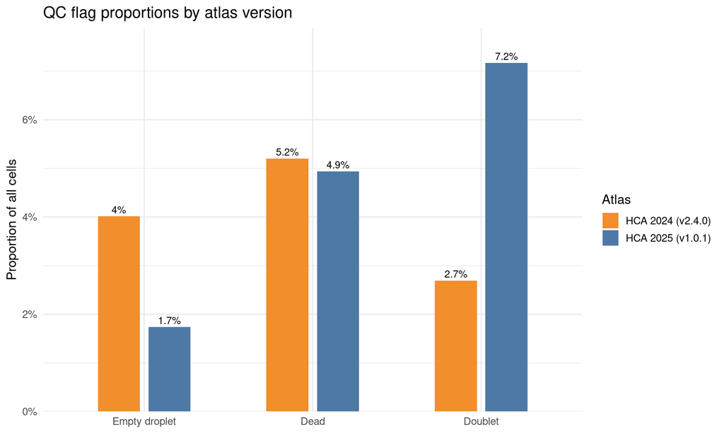

```r
qc_long <- qc_summary |>
  select(atlas_id, pct_empty, pct_dead, pct_doublet) |>
  pivot_longer(-atlas_id, names_to = "flag", values_to = "proportion") |>
  mutate(flag = recode(flag,
    pct_empty   = "Empty droplet",
    pct_dead    = "Dead",
    pct_doublet = "Doublet"
  )) |>
  mutate(
    flag = factor(flag, levels = c("Empty droplet", "Dead", "Doublet"))
  )

ggplot(qc_long, aes(x = flag, y = proportion, fill = atlas_id)) +
  geom_col(position = position_dodge(width = 0.6), width = 0.5) +
  geom_text(
    aes(label = pct(proportion, 1)),
    position = position_dodge(width = 0.6),
    vjust = -0.4, size = 3.5
  ) +
  scale_fill_manual(values = pal, labels = atlas_labels, name = "Atlas") +
  scale_y_continuous(labels = percent_format(), expand = expansion(mult = c(0, 0.1))) +
  labs(
    title = "QC flag proportions by atlas version",
    x = NULL, y = "Proportion of all cells"
  ) +
  theme_minimal(base_size = 13)
```

## 5 Demographic Overview

### 5.1 Sex distribution

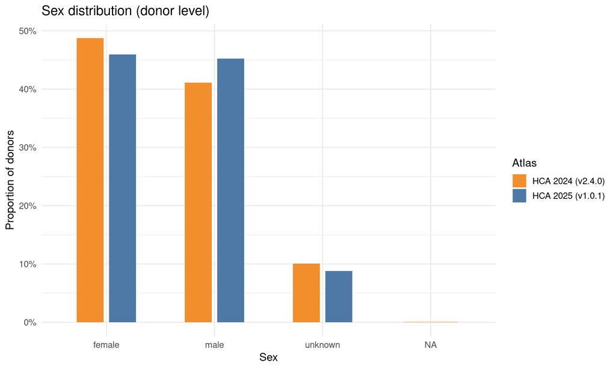

```r
sex_dist <- cells |>
  distinct(atlas_id, donor_id, sex) |>
  group_by(atlas_id, sex) |>
  summarise(n = n(), .groups = "drop") |>
  collect() |>
  group_by(atlas_id) |>
  mutate(pct = n / sum(n))

ggplot(sex_dist, aes(x = sex, y = pct, fill = atlas_id)) +
  geom_col(position = position_dodge(width = 0.6), width = 0.5) +
  scale_fill_manual(values = pal, labels = atlas_labels, name = "Atlas") +
  scale_y_continuous(labels = percent_format()) +
  labs(title = "Sex distribution (donor level)", x = "Sex", y = "Proportion of donors") +
  theme_minimal(base_size = 13)
```

### 5.2 Donors by tissue (2024 base + 2025 additional)

Stacked bars per tissue: **2024** donor count (left), plus **2025-only** donors for that tissue (right; not present in 2024 for the same tissue). Top 40 tissues by total bar height.

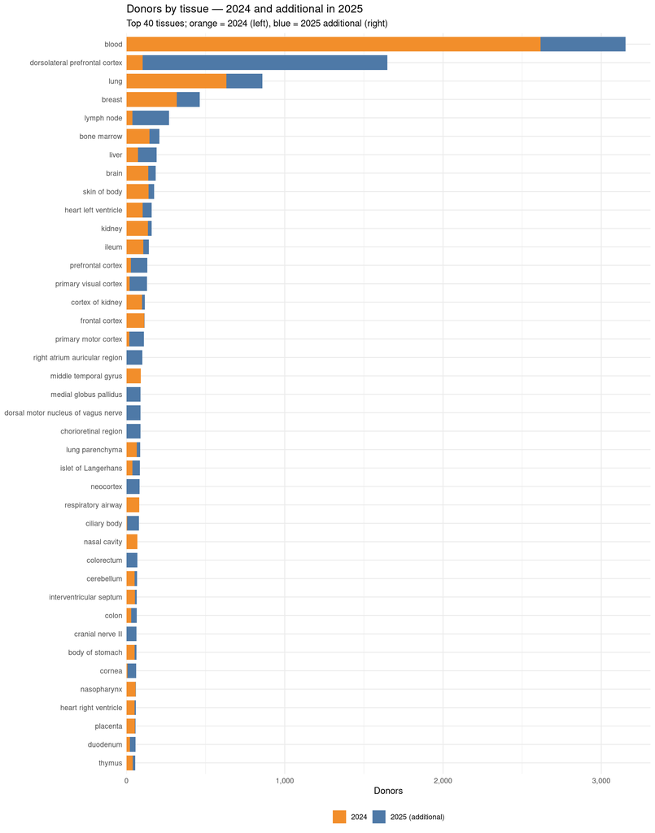

```r
donors_2024_by_tissue <- cells |>
  filter(atlas_id == id_2024, !is.na(tissue), tissue != "") |>
  distinct(tissue, donor_id) |>
  collect()

donors_2025_by_tissue <- cells |>
  filter(atlas_id == id_2025, !is.na(tissue), tissue != "") |>
  distinct(tissue, donor_id) |>
  collect()

donors_2024_counts <- donors_2024_by_tissue |>
  count(tissue, name = "n_2024")

donors_2025_extra_by_tissue <- donors_2025_by_tissue |>
  anti_join(donors_2024_by_tissue, by = c("tissue", "donor_id")) |>
  count(tissue, name = "n_2025_extra")

donor_tissue_wide <- donors_2024_counts |>
  full_join(donors_2025_extra_by_tissue, by = "tissue") |>
  mutate(
    n_2024 = replace_na(n_2024, 0L),
    n_2025_extra = replace_na(n_2025_extra, 0L),
    tissue = str_trunc(tissue, 50),
    total = n_2024 + n_2025_extra
  ) |>
  slice_max(total, n = 40, with_ties = FALSE)

plot_2024_2025_stack(
  donor_tissue_wide,
  y_var = "tissue",
  xlab = "Donors",
  title = "Donors by tissue — 2024 and additional in 2025",
  subtitle = "Top 40 tissues; orange = 2024 (left), blue = 2025 additional (right)"
)
```

### 5.3 Datasets by tissue (2024 base + 2025 additional)

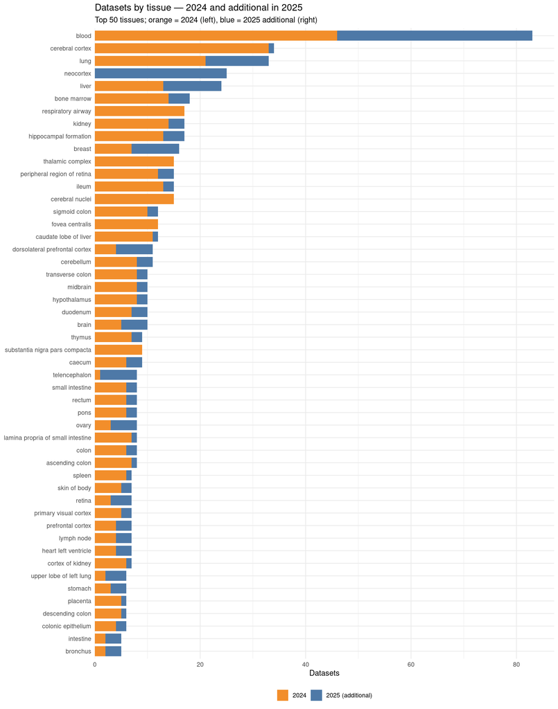

```r
datasets_2024_by_tissue <- cells |>
  filter(atlas_id == id_2024, !is.na(tissue), tissue != "") |>
  distinct(tissue, dataset_id) |>
  collect()

datasets_2025_by_tissue <- cells |>
  filter(atlas_id == id_2025, !is.na(tissue), tissue != "") |>
  distinct(tissue, dataset_id) |>
  collect()

datasets_2024_counts <- datasets_2024_by_tissue |>
  count(tissue, name = "n_2024")

datasets_2025_extra_by_tissue <- datasets_2025_by_tissue |>
  anti_join(datasets_2024_by_tissue, by = c("tissue", "dataset_id")) |>
  count(tissue, name = "n_2025_extra")

dataset_tissue_wide <- datasets_2024_counts |>
  full_join(datasets_2025_extra_by_tissue, by = "tissue") |>
  mutate(
    n_2024 = replace_na(n_2024, 0L),
    n_2025_extra = replace_na(n_2025_extra, 0L),
    tissue = str_trunc(tissue, 50),
    total = n_2024 + n_2025_extra
  ) |>
  slice_max(total, n = 50, with_ties = FALSE)

plot_2024_2025_stack(
  dataset_tissue_wide,
  y_var = "tissue",
  xlab = "Datasets",
  title = "Datasets by tissue — 2024 and additional in 2025",
  subtitle = "Top 50 tissues; orange = 2024 (left), blue = 2025 additional (right)"
)
```

### 5.4 Donors by tissue group (2024 base + 2025 additional)

Same stacked layout as §5.2, using `tissue_groups`.

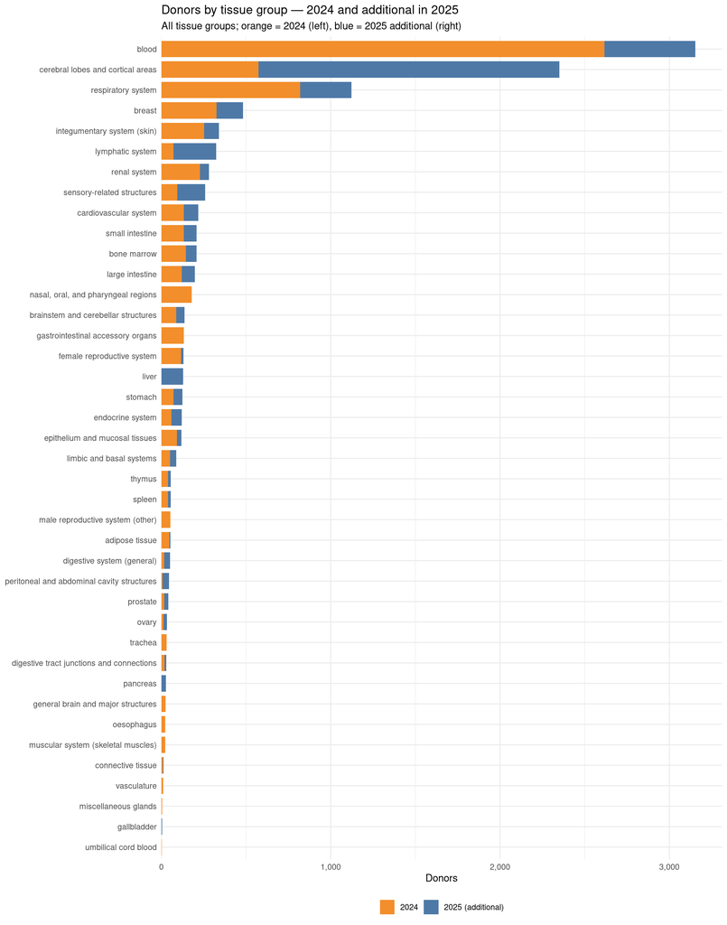

```r
donors_2024_by_tg <- cells |>
  filter(atlas_id == id_2024, !is.na(tissue_groups), tissue_groups != "") |>
  distinct(tissue_groups, donor_id) |>
  collect()

donors_2025_by_tg <- cells |>
  filter(atlas_id == id_2025, !is.na(tissue_groups), tissue_groups != "") |>
  distinct(tissue_groups, donor_id) |>
  collect()

donors_2024_tg_counts <- donors_2024_by_tg |>
  count(tissue_groups, name = "n_2024")

donors_2025_extra_by_tg <- donors_2025_by_tg |>
  anti_join(donors_2024_by_tg, by = c("tissue_groups", "donor_id")) |>
  count(tissue_groups, name = "n_2025_extra")

donor_tg_wide <- donors_2024_tg_counts |>
  full_join(donors_2025_extra_by_tg, by = "tissue_groups") |>
  mutate(
    n_2024 = replace_na(n_2024, 0L),
    n_2025_extra = replace_na(n_2025_extra, 0L),
    tissue_groups = str_trunc(tissue_groups, 50),
    total = n_2024 + n_2025_extra
  )

plot_2024_2025_stack(
  donor_tg_wide,
  y_var = "tissue_groups",
  xlab = "Donors",
  title = "Donors by tissue group — 2024 and additional in 2025",
  subtitle = "All tissue groups; orange = 2024 (left), blue = 2025 additional (right)"
)
```

### 5.5 Datasets by tissue group (2024 base + 2025 additional)

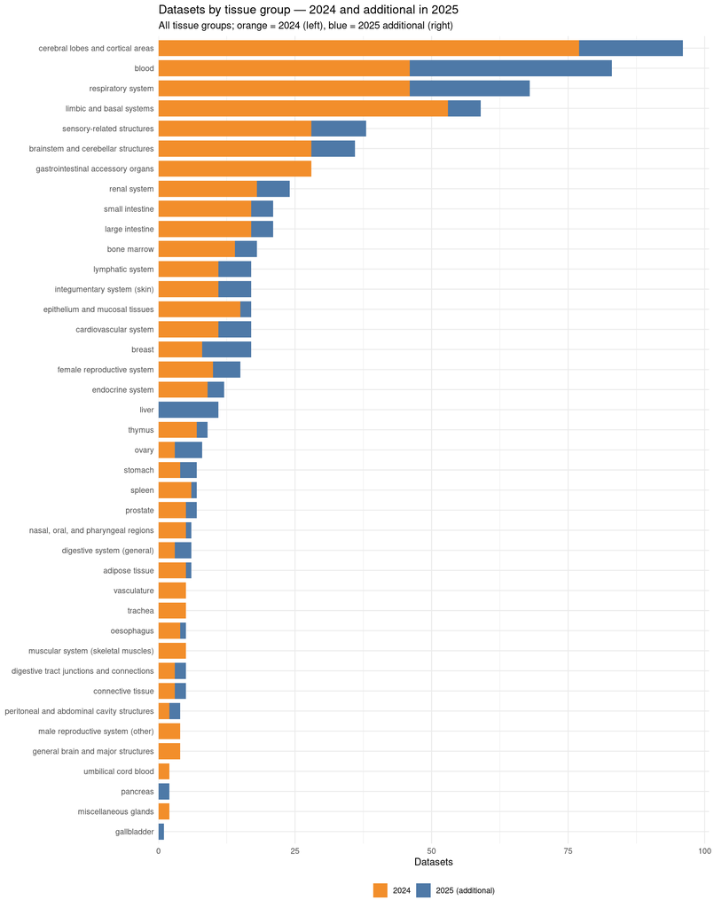

```r
datasets_2024_by_tg <- cells |>
  filter(atlas_id == id_2024, !is.na(tissue_groups), tissue_groups != "") |>
  distinct(tissue_groups, dataset_id) |>
  collect()

datasets_2025_by_tg <- cells |>
  filter(atlas_id == id_2025, !is.na(tissue_groups), tissue_groups != "") |>
  distinct(tissue_groups, dataset_id) |>
  collect()

datasets_2024_tg_counts <- datasets_2024_by_tg |>
  count(tissue_groups, name = "n_2024")

datasets_2025_extra_by_tg <- datasets_2025_by_tg |>
  anti_join(datasets_2024_by_tg, by = c("tissue_groups", "dataset_id")) |>
  count(tissue_groups, name = "n_2025_extra")

dataset_tg_wide <- datasets_2024_tg_counts |>
  full_join(datasets_2025_extra_by_tg, by = "tissue_groups") |>
  mutate(
    n_2024 = replace_na(n_2024, 0L),
    n_2025_extra = replace_na(n_2025_extra, 0L),
    tissue_groups = str_trunc(tissue_groups, 50),
    total = n_2024 + n_2025_extra
  )

plot_2024_2025_stack(
  dataset_tg_wide,
  y_var = "tissue_groups",
  xlab = "Datasets",
  title = "Datasets by tissue group — 2024 and additional in 2025",
  subtitle = "All tissue groups; orange = 2024 (left), blue = 2025 additional (right)"
)
```

### 5.6 Self-reported ethnicity

Comparisons use **distinct ethnicity labels** and **donor counts** between atlas versions.

```r
eth_2024 <- cells |>
  filter(
    atlas_id == id_2024,
    !is.na(self_reported_ethnicity),
    self_reported_ethnicity != ""
  ) |>
  distinct(donor_id, self_reported_ethnicity) |>
  collect()

eth_2025 <- cells |>
  filter(
    atlas_id == id_2025,
    !is.na(self_reported_ethnicity),
    self_reported_ethnicity != ""
  ) |>
  distinct(donor_id, self_reported_ethnicity) |>
  collect()

eth_labels_2024 <- unique(eth_2024$self_reported_ethnicity)
eth_labels_2025 <- unique(eth_2025$self_reported_ethnicity)
eth_labels_both <- intersect(eth_labels_2024, eth_labels_2025)
eth_labels_only_2024 <- setdiff(eth_labels_2024, eth_labels_2025)
eth_labels_only_2025 <- setdiff(eth_labels_2025, eth_labels_2024)

eth_2024_counts <- eth_2024 |>
  count(self_reported_ethnicity, name = "n_2024")

eth_2025_extra <- eth_2025 |>
  anti_join(eth_2024, by = c("self_reported_ethnicity", "donor_id")) |>
  count(self_reported_ethnicity, name = "n_2025_extra")

eth_wide <- eth_2024_counts |>
  full_join(eth_2025_extra, by = "self_reported_ethnicity") |>
  mutate(
    n_2024 = replace_na(n_2024, 0L),
    n_2025_extra = replace_na(n_2025_extra, 0L),
    self_reported_ethnicity = str_trunc(self_reported_ethnicity, 40),
    total = n_2024 + n_2025_extra
  )

eth_new_2025_donors <- eth_2025 |>
  filter(self_reported_ethnicity %in% eth_labels_only_2025) |>
  count(self_reported_ethnicity, name = "n_donors") |>
  arrange(desc(n_donors)) |>
  mutate(self_reported_ethnicity = str_trunc(self_reported_ethnicity, 50))
```

#### 5.6.1 Donor counts by ethnicity (stacked 2024 + 2025 additional)

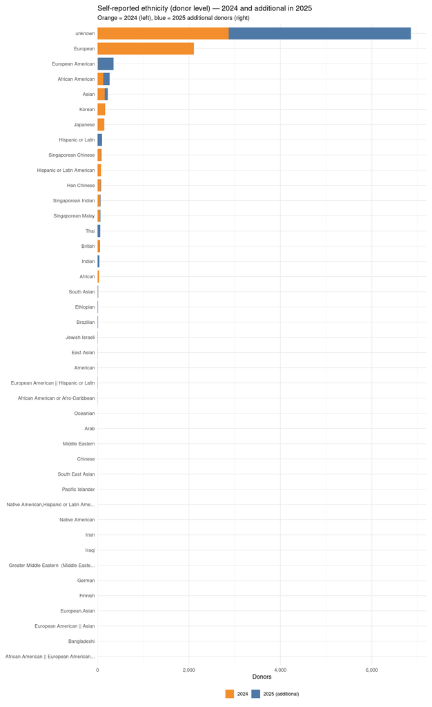

```r
plot_2024_2025_stack(
  eth_wide,
  y_var = "self_reported_ethnicity",
  xlab = "Donors",
  title = "Self-reported ethnicity (donor level) — 2024 and additional in 2025",
  subtitle = "Orange = 2024 (left), blue = 2025 additional donors (right)"
) +
  theme(plot.margin = margin(10, 10, 10, 10))
```

#### 5.6.2 Ethnicity label overlap (2024 vs 2025)

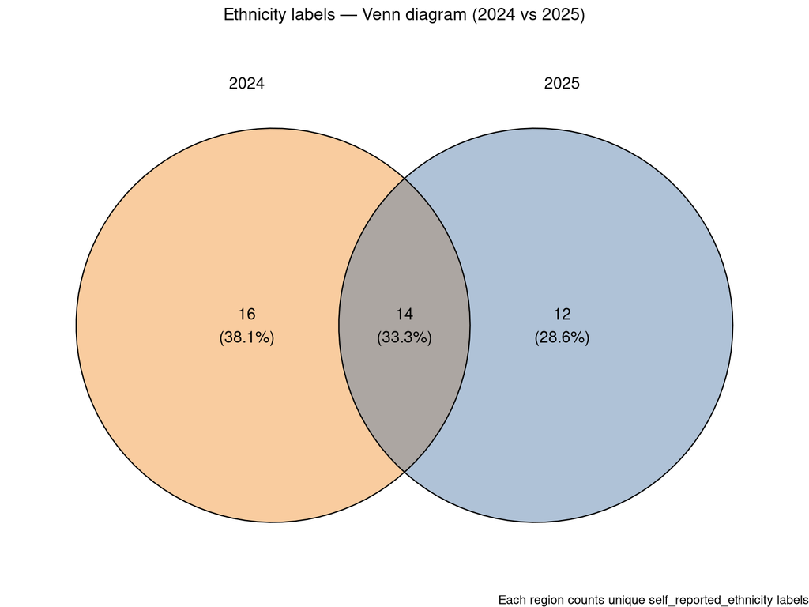

```r
eth_venn_sets <- list(
  `2024` = eth_labels_2024,
  `2025` = eth_labels_2025
)

ggvenn::ggvenn(
    eth_venn_sets,
    fill_color = c(stack_cols["2024"], stack_cols["2025_extra"]),
    fill_alpha = 0.45,
    stroke_size = 0.4,
    set_name_size = 4,
    text_size = 4
  ) +
    labs(
      title = "Ethnicity labels — Venn diagram (2024 vs 2025)",
      caption = "Each region counts unique self_reported_ethnicity labels"
    ) +
    theme(plot.title = element_text(size = 12, hjust = 0.5))
```

#### 5.6.3 New ethnicity labels in 2025

Ethnicity labels present in **2025** but not in **2024**, with donor counts in the 2025 atlas.

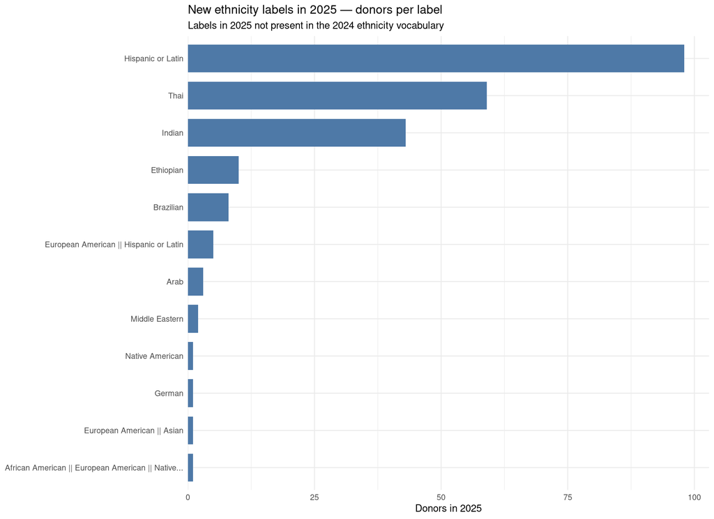

```r
if (nrow(eth_new_2025_donors) > 0) {
  ggplot(
    eth_new_2025_donors,
    aes(x = n_donors, y = reorder(self_reported_ethnicity, n_donors))
  ) +
    geom_col(fill = stack_cols["2025_extra"], width = 0.75) +
    scale_x_continuous(labels = comma, expand = expansion(mult = c(0, 0.05))) +
    labs(
      title = "New ethnicity labels in 2025 — donors per label",
      subtitle = "Labels in 2025 not present in the 2024 ethnicity vocabulary",
      x = "Donors in 2025", y = NULL
    ) +
    theme_minimal(base_size = 11)
}
```

### 5.7 Age distribution (age_days)

```r
donors <- cells |>
  distinct(atlas_id, donor_id, age_days) |>
  collect()

age_stats <- donors |>
  group_by(atlas_id) |>
  summarise(
    n_donors    = sum(as.integer(!is.na(age_days))),
    mean_age    = mean(age_days, na.rm = TRUE),
    median_age  = median(age_days, na.rm = TRUE),
    min_age     = min(age_days, na.rm = TRUE),
    max_age     = max(age_days, na.rm = TRUE),
    .groups = "drop"
  )
```

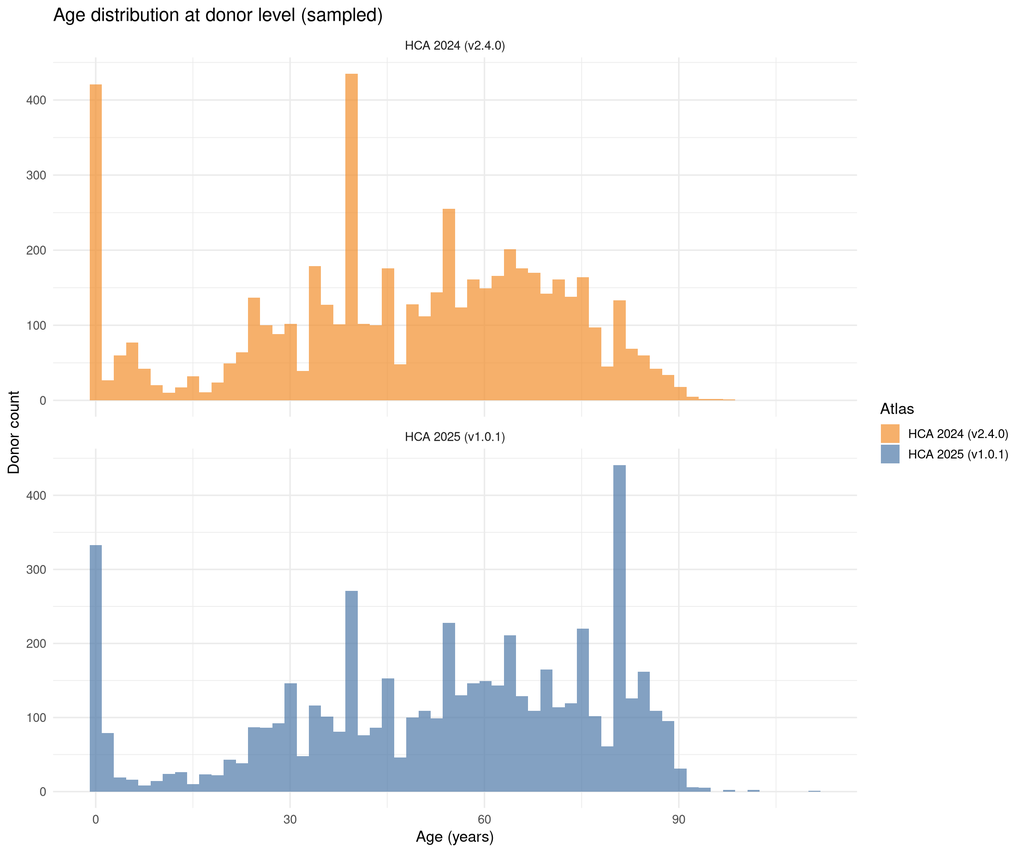

```r
age_non_na <- donors |> filter(!is.na(age_days))
age_sample <- slice_sample(
  age_non_na,
  n = min(200000L, nrow(age_non_na)),
  replace = FALSE
)

ggplot(age_sample, aes(x = age_days / 365.25, fill = atlas_id)) +
  geom_histogram(bins = 60, alpha = 0.7, position = "identity") +
  scale_fill_manual(values = pal, labels = atlas_labels, name = "Atlas") +
  scale_x_continuous(labels = comma) +
  labs(
    title = "Age distribution at donor level (sampled)",
    x = "Age (years)", y = "Donor count"
  ) +
  theme_minimal(base_size = 13) +
  facet_wrap(
    ~atlas_id, ncol = 1, scales = "free_y",
    labeller = labeller(atlas_id = atlas_labels)
  )
```

## 6 QC per Assay

```r
qc_assay <- cells |>
  #filter(!str_detect(assay, fixed("ScaleBio"))) |>
  group_by(atlas_id, assay) |>
  summarise(
    total_cells = n(),
    empty_cells = sum(as.integer(empty_droplet == TRUE), na.rm = TRUE),
    alive_cells = sum(as.integer(alive == TRUE), na.rm = TRUE),
    dead_cells  = sum(as.integer(empty_droplet == FALSE & alive == FALSE), na.rm = TRUE),
    doublet     = sum(as.integer(
      empty_droplet == FALSE & scDblFinder.class == "doublet"
    ), na.rm = TRUE),
    .groups = "drop"
  ) |>
  collect() |>
  mutate(
    assay_short = str_trunc(assay, 45),
    pct_empty   = empty_cells / total_cells,
    pct_alive   = alive_cells / total_cells,
    pct_dead    = dead_cells  / total_cells,
    pct_doublet = doublet     / total_cells
  ) |>
  select(-assay)

top_assays_by_atlas <- qc_assay |>
  group_by(atlas_id, assay_short) |>
  slice_max(total_cells, n = 15, with_ties = FALSE) |>
  ungroup() |>
  select(atlas_id, assay_short)

qc_assay_top <- qc_assay |>
  inner_join(top_assays_by_atlas, by = c("atlas_id", "assay_short")) |>
  mutate(
    bad_cells = empty_cells + dead_cells + doublet,
    pct_bad   = bad_cells / total_cells
  )

qc_per_assay_long <- qc_assay_top |>
  mutate(
    `Empty Droplet` = round(pct_empty * 100, 2),
    `Alive Cells`   = round(pct_alive * 100, 2),
    `Dead`          = round(pct_dead * 100, 2),
    `Doublet`       = round(pct_doublet * 100, 2)
  ) |>
  pivot_longer(
    cols = c("Empty Droplet", "Alive Cells", "Dead", "Doublet"),
    names_to = "Group",
    values_to = "Percentage"
  )
```

```r
plot_qc_stack_atlas <- function(data, atlas, x_order) {
  order_subtitle <- if (identical(x_order, "pct_bad")) {
    "; ordered by bad-cell % (empty + dead + doublet)"
  } else if (identical(x_order, "total_cells")) {
    "; ordered by cell count"
  } else {
    ""
  }

  plot_data <- data |>
    filter(atlas_id == atlas, Group != "Alive Cells") |>
    mutate(
      Group = factor(
        Group,
        levels = c("Empty Droplet", "Dead", "Doublet")
      )
    )

  ggplot(
    plot_data,
    aes(
      x = reorder(assay_short, -!!rlang::sym(x_order)),
      y = Percentage,
      fill = Group
    )
  ) +
    geom_col(position = "stack", stat = "identity", width = 0.75) +
    scale_fill_manual(values = cell_quality_cols, name = "QC category") +
    scale_y_continuous(expand = expansion(mult = c(0, 0.05))) +
    labs(
      title = atlas_labels[[atlas]],
      subtitle = paste0(
        "Top 15 assays in this atlas; alive cells omitted from stack",
        order_subtitle
      ),
      x = "Technology", y = "Cell percentage (%)"
    ) +
    theme_minimal(base_size = 13) +
    theme(
      axis.text.x = element_text(size = 9, angle = 45, hjust = 1),
      legend.position = "bottom",
      legend.text = element_text(size = 11),
      plot.title = element_text(size = 14),
      plot.subtitle = element_text(size = 11)
    )
}
```

### 6.1 Stacked QC composition per assay

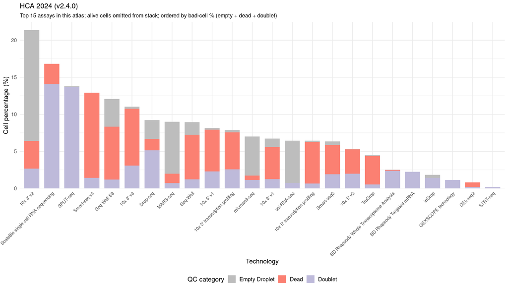

```r
plot_qc_stack_atlas(qc_per_assay_long, atlas_ids[str_detect(atlas_ids, "2024")][1], "pct_bad")
```

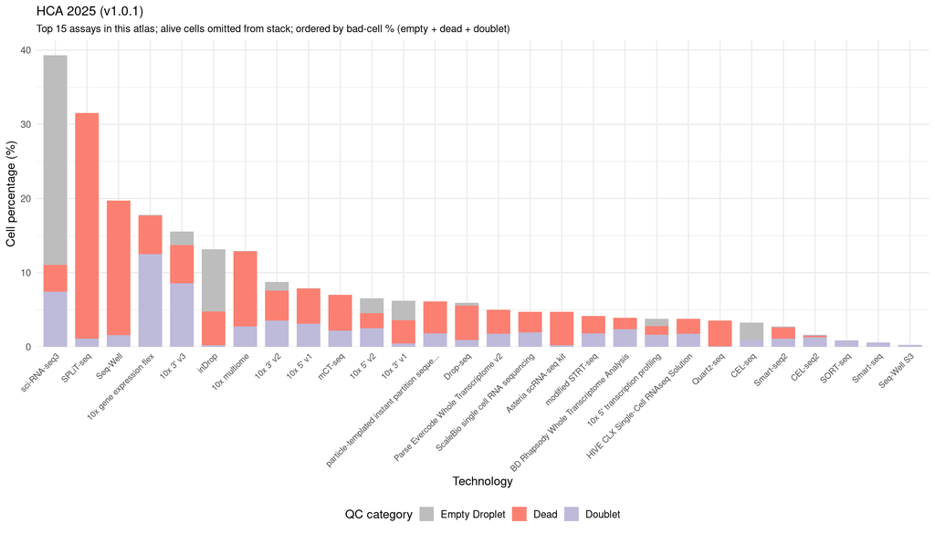

```r
plot_qc_stack_atlas(qc_per_assay_long, atlas_ids[str_detect(atlas_ids, "2025")][1], "pct_bad")
```

## 7 Missing-Value Audit for QC Columns (development)

This appendix is for **development and pipeline debugging** only — it checks NA rates in QC columns to validate whether missing values indicate a pipeline bug.

```r
missing_audit <- qc_summary |>
  select(atlas_id, total, n_empty_na, n_alive_na, n_dbl_na) |>
  mutate(
    pct_empty_na = pct(n_empty_na / total),
    pct_alive_na = pct(n_alive_na / total),
    pct_dbl_na   = pct(n_dbl_na   / total)
  )

missing_audit |>
  select(atlas_id, n_empty_na, pct_empty_na, n_alive_na, pct_alive_na, n_dbl_na, pct_dbl_na) |>
  kbl(
    col.names = c("atlas_id",
                  "empty_droplet NA", "%",
                  "alive NA", "%",
                  "scDblFinder.class NA", "%"),
    caption = "Missing values in QC columns"
  ) |>
  kable_styling(bootstrap_options = c("striped", "hover"), full_width = FALSE)
```

Missing values in QC columns

| atlas_id | empty_droplet NA | % | alive NA | % | scDblFinder.class NA | % |
| --- | --- | --- | --- | --- | --- | --- |
| hca_2024/0.5.0 | 0 | 0% | 1765735 | 4.01% | 1765735 | 4.01% |
| hca_2025/0.2.0 | 0 | 0% | 881475 | 1.74% | 881475 | 1.74% |